# Homework2

Ezgi ORAL

11 12 2020

Reading Data:

```r
uWaveGestureLibrary_X_TRAIN <- read_table2("UWave/uWaveGestureLibrary_X_TRAIN", col_names = FALSE)
#View(uWaveGestureLibrary_X_TRAIN)

uWaveGestureLibrary_Y_TRAIN <- read_table2("UWave/uWaveGestureLibrary_Y_TRAIN", col_names = FALSE)
#View(uWaveGestureLibrary_Y_TRAIN)

uWaveGestureLibrary_Z_TRAIN <- read_table2("UWave/uWaveGestureLibrary_Z_TRAIN", col_names = FALSE)
#View(uWaveGestureLibrary_Z_TRAIN)


dataX<-uWaveGestureLibrary_X_TRAIN
dataY<-uWaveGestureLibrary_Y_TRAIN
dataZ<-uWaveGestureLibrary_Z_TRAIN
noOfTimeIndex = NCOL(dataX[,-1])
noOfCol = NROW(dataX)
```

## PART A

Observing every class (gesture) from some sample instances:

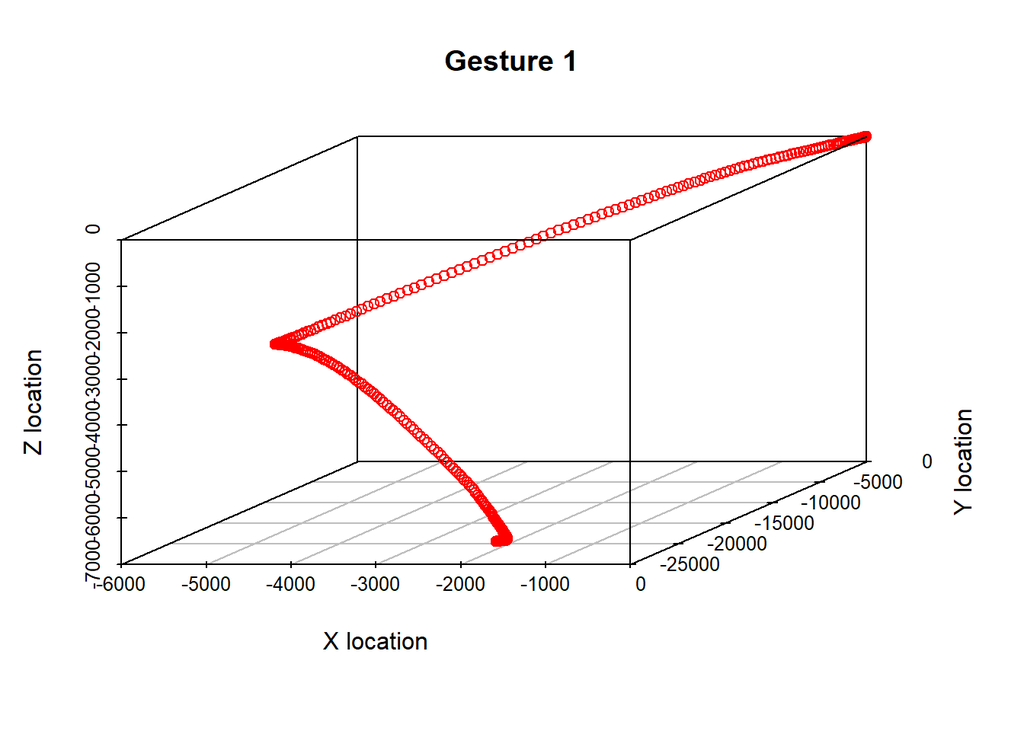

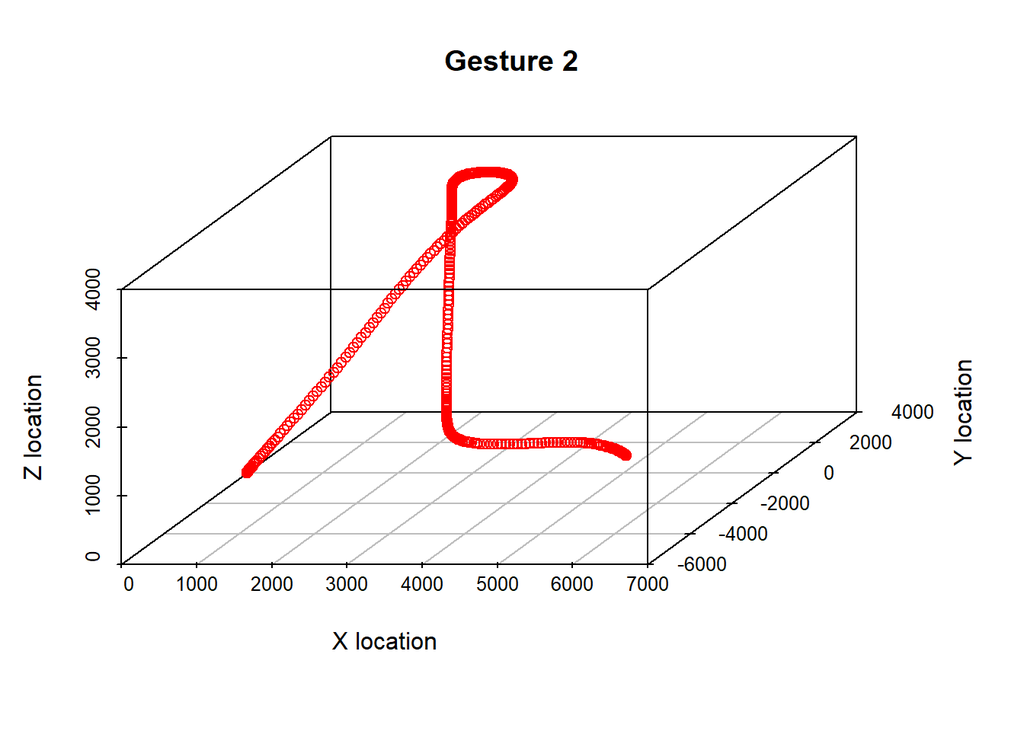

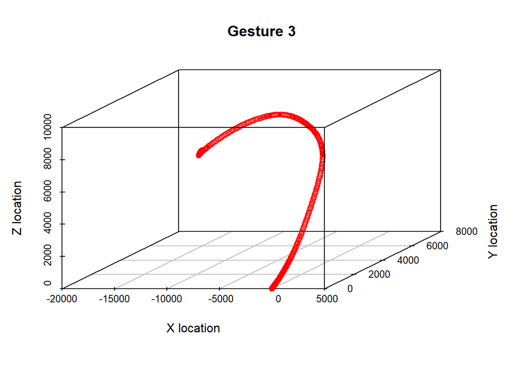

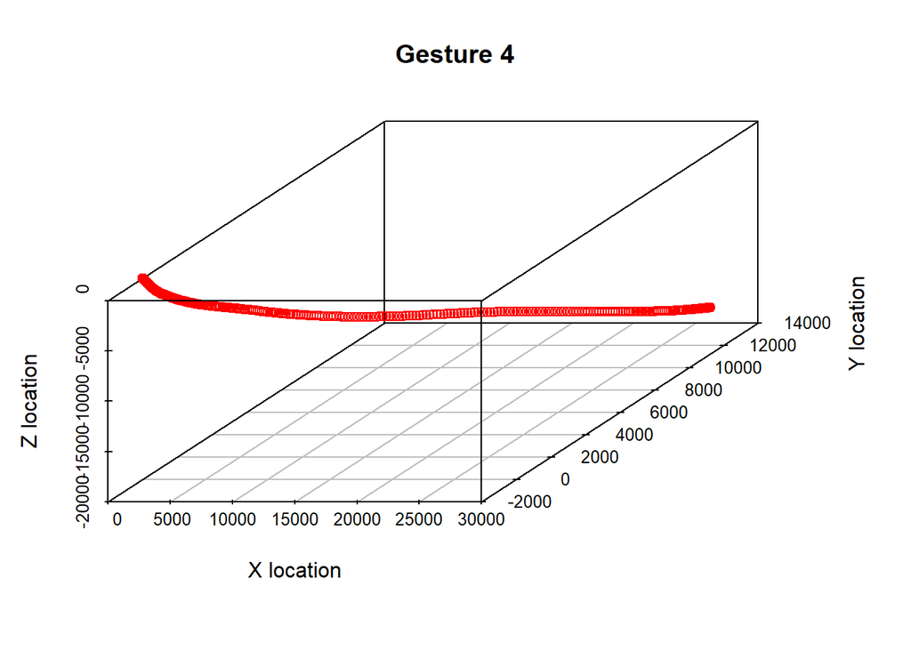

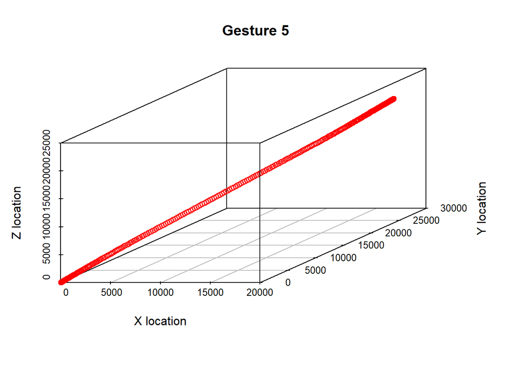

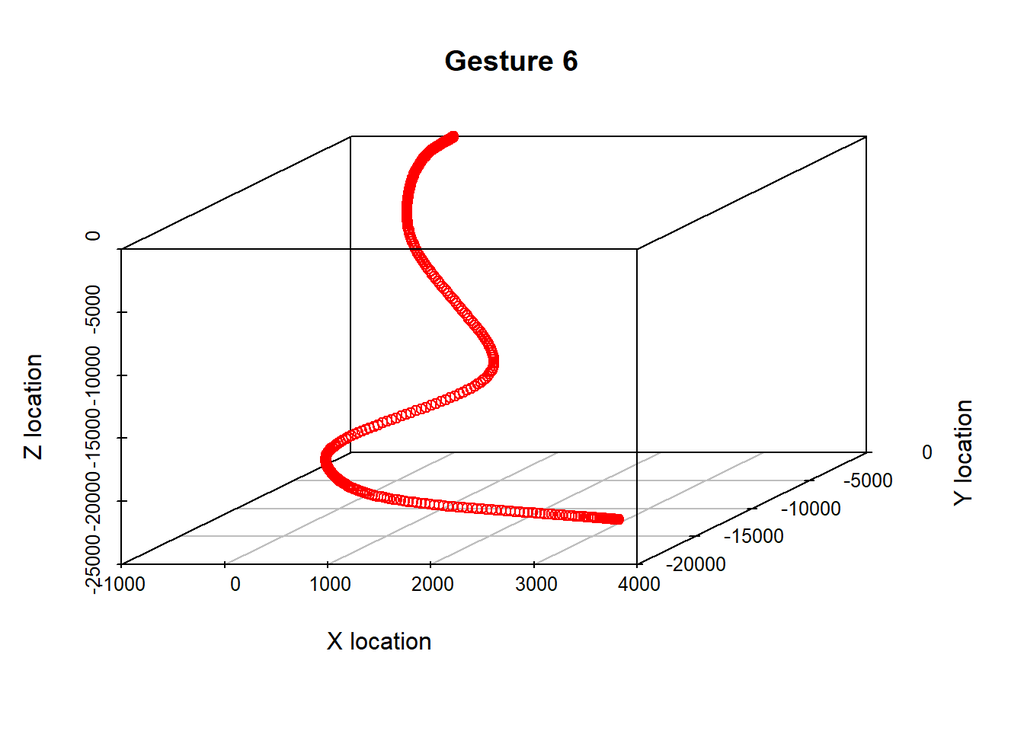

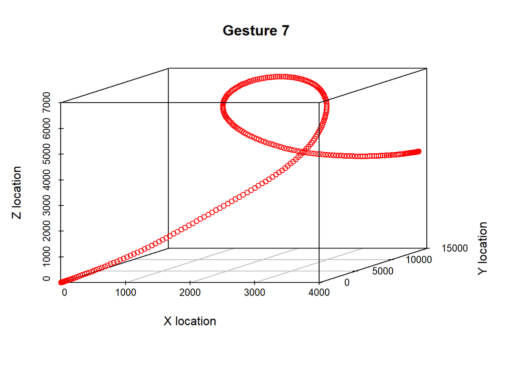

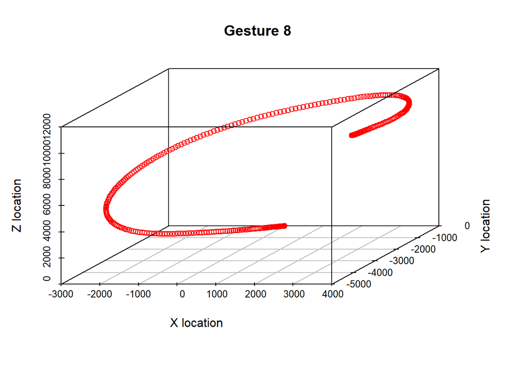

```r
sampleInstances <- c(11, 15, 4, 5, 2, 1, 7, 6) # classes 1...8

for(i in 1:8) #8 classes
{
  instance <- sampleInstances[i]
  class<-as.numeric(dataX[instance,1])
  accData<-t(rbind(dataX[instance,-1],dataY[instance,-1],dataZ[instance,-1]))


Velocity <- matrix(0,3,noOfTimeIndex)
Location <- matrix(0,3,noOfTimeIndex)

k=1
for(j in 1:3)
{
  Velocity[k,] <- cumsum(accData[,j])
  k=k+1
}


p=1
for(m in 1:3)
{
  Location[p,] <- cumsum(t(Velocity)[,m])
  p=p+1
}


scatterplot3d(t(Location)[,1],t(Location)[,2],t(Location)[,3],main = paste("Gesture", i),xlab = "X location",ylab = "Y location",zlab = "Z location", type = "p", color = "red")
}
```

While looking at the figures, please keep in mind that we are able to access the start point and the end point.

In “Gesture 1” figure, we observe the 90 degree turn, so this instance fits with Gesture 1 perfectly. In “Gesture 2” figure, it is seen that there exists 3 sharp 90 degree turns, so it can be said that this instance fits with Gesture 2 perfectly. In “Gesture 3” figure, it is not very obvious but, by changing the viewing angle we can observe Gesture 3 with the chosen instance. In “Gesture 4” figure, we can observe Gesture 4 very clearly from this instance. In “Gesture 5” figure, we can see that points are moving upwards, so this instance fits with Gesture 5. In “Gesture 6” figure, it is seen that points are moving downwards. This instance fits with Gesture 6. For “Gesture 7” and “Gesture 8” figures, we can observe the 360 degree change. Simply by looking at the start and end point for that instance, we can see that they also fit perfectly with their corresponding gestures.

## PART B

We apply PCA for data reduction. Both “prcomp” and “princomp” functions can be used for PCA however, I preferred prcomp.

```r
combineAll<-cbind(1,1:noOfTimeIndex,t(dataX[1,-1]),t(dataY[1,-1]),t(dataZ[1,-1]),as.numeric(dataX[1,1])) #initialize

for(s in 2:noOfCol)
{

  temp<-cbind(s,1:noOfTimeIndex,t(dataX[s,-1]),t(dataY[s,-1]),t(dataZ[s,-1]),as.numeric(dataX[s,1]))
  combineAll<-rbind(combineAll,temp)
}
colnames(combineAll,do.NULL = TRUE, prefix = "col")
```

```
## [1] "s" ""  ""  ""  ""  ""
```

```r
colnames(combineAll)<-c("Time Series ID", "Time Index","X","Y","Z","Class")

dataForPartB<-cbind(combineAll[,3],combineAll[,4],combineAll[,5])
pcaPartB<-prcomp(dataForPartB, scale. = TRUE)
summary(pcaPartB)
```

```
## Importance of components:
##                           PC1    PC2    PC3
## Standard deviation     1.2132 1.0199 0.6986
## Proportion of Variance 0.4906 0.3467 0.1627
## Cumulative Proportion  0.4906 0.8373 1.0000
```

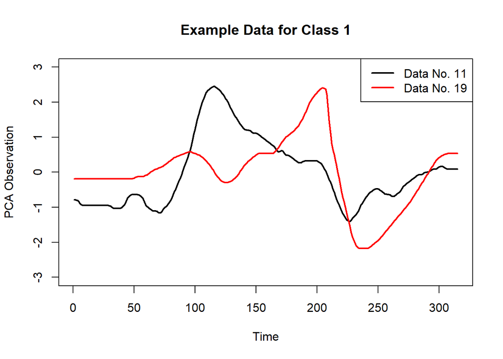

```r
randomChoiceClass1_1<-11
randomChoiceClass1_2<-19

randomChoiceClass2_1<-15
randomChoiceClass2_2<-20

randomChoiceClass3_1<-27
randomChoiceClass3_2<-61

randomChoiceClass4_1<-5
randomChoiceClass4_2<-51

randomChoiceClass5_1<-2
randomChoiceClass5_2<-3

randomChoiceClass6_1<-1
randomChoiceClass6_2<-10

randomChoiceClass7_1<-7
randomChoiceClass7_2<-32

randomChoiceClass8_1<-21
randomChoiceClass8_2<-40

t1_1<-seq(((randomChoiceClass1_1-1)*noOfTimeIndex+1),randomChoiceClass1_1*noOfTimeIndex)
t1_2<-seq(((randomChoiceClass1_2-1)*noOfTimeIndex+1) ,randomChoiceClass1_2*noOfTimeIndex)

t2_1<-seq(((randomChoiceClass2_1-1)*noOfTimeIndex+1),randomChoiceClass2_1*noOfTimeIndex)
t2_2<-seq(((randomChoiceClass2_2-1)*noOfTimeIndex+1) ,randomChoiceClass2_2*noOfTimeIndex)

t3_1<-seq(((randomChoiceClass3_1-1)*noOfTimeIndex+1),randomChoiceClass3_1*noOfTimeIndex)
t3_2<-seq(((randomChoiceClass3_2-1)*noOfTimeIndex+1) ,randomChoiceClass3_2*noOfTimeIndex)

t4_1<-seq(((randomChoiceClass4_1-1)*noOfTimeIndex+1),randomChoiceClass4_1*noOfTimeIndex)
t4_2<-seq(((randomChoiceClass4_2-1)*noOfTimeIndex+1) ,randomChoiceClass4_2*noOfTimeIndex)

t5_1<-seq(((randomChoiceClass5_1-1)*noOfTimeIndex+1),randomChoiceClass5_1*noOfTimeIndex)
t5_2<-seq(((randomChoiceClass5_2-1)*noOfTimeIndex+1) ,randomChoiceClass5_2*noOfTimeIndex)

t6_1<-seq(((randomChoiceClass6_1-1)*noOfTimeIndex+1),randomChoiceClass6_1*noOfTimeIndex)
t6_2<-seq(((randomChoiceClass6_2-1)*noOfTimeIndex+1) ,randomChoiceClass6_2*noOfTimeIndex)

t7_1<-seq(((randomChoiceClass7_1-1)*noOfTimeIndex+1),randomChoiceClass7_1*noOfTimeIndex)
t7_2<-seq(((randomChoiceClass7_2-1)*noOfTimeIndex+1),randomChoiceClass7_2*noOfTimeIndex)

t8_1<-seq(((randomChoiceClass8_1-1)*noOfTimeIndex+1),randomChoiceClass8_1*noOfTimeIndex)
t8_2<-seq(((randomChoiceClass8_2-1)*noOfTimeIndex+1),randomChoiceClass8_2*noOfTimeIndex)

time<-1:noOfTimeIndex
plot(time, dataForPartB[t1_1,1], type = "l", ylim=c(-3, 3), lwd=2, main = "Example Data for Class 1", xlab="Time", ylab="PCA Observation")
lines(time, dataForPartB[t1_2,1], col="red", lwd=2)
legend("topright", legend = c(paste("Data No.",randomChoiceClass1_1) , paste("Data No.",randomChoiceClass1_2)),
       col = c("black", "red"), lty = 1:1, lwd = 2)
```

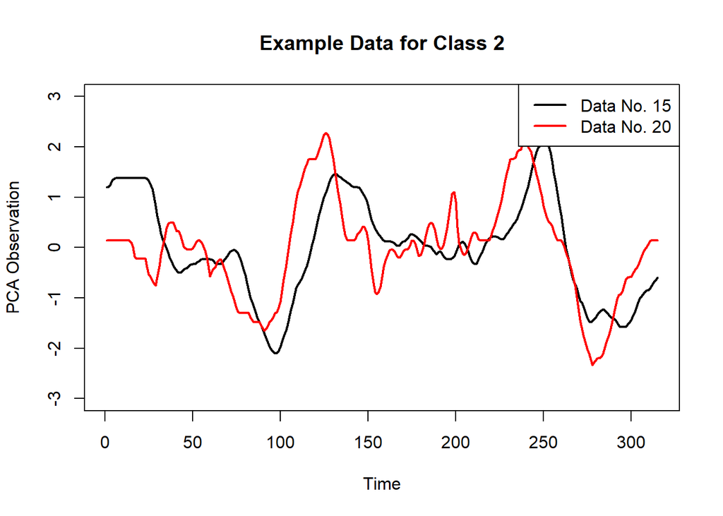

```r
plot(time, dataForPartB[t2_1,1], type = "l", ylim=c(-3, 3), lwd=2, main = "Example Data for Class 2", xlab="Time", ylab="PCA Observation")
lines(time, dataForPartB[t2_2,1], col="red", lwd=2)
legend("topright", legend = c(paste("Data No.",randomChoiceClass2_1) , paste("Data No.",randomChoiceClass2_2)),
       col = c("black", "red"), lty = 1:1, lwd = 2)
```

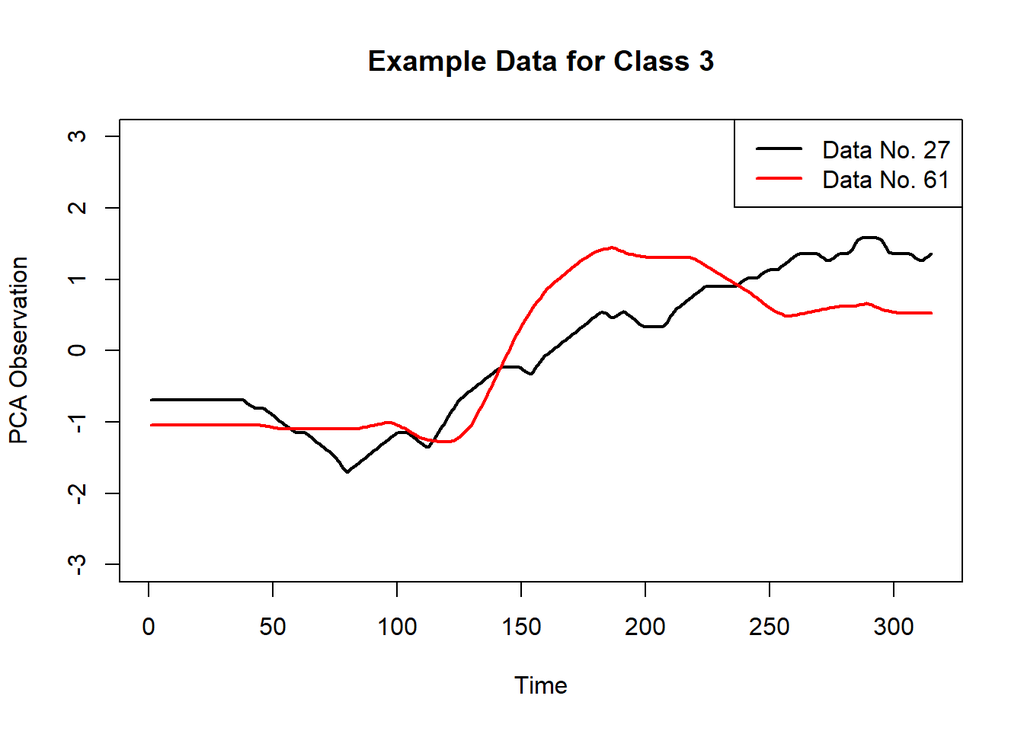

```r
plot(time, dataForPartB[t3_1,1], type = "l", ylim=c(-3, 3), lwd=2, main = "Example Data for Class 3", xlab="Time", ylab="PCA Observation")
lines(time, dataForPartB[t3_2,1], col="red", lwd=2)
legend("topright", legend = c(paste("Data No.",randomChoiceClass3_1) , paste("Data No.",randomChoiceClass3_2)),
       col = c("black", "red"), lty = 1:1, lwd = 2)
```

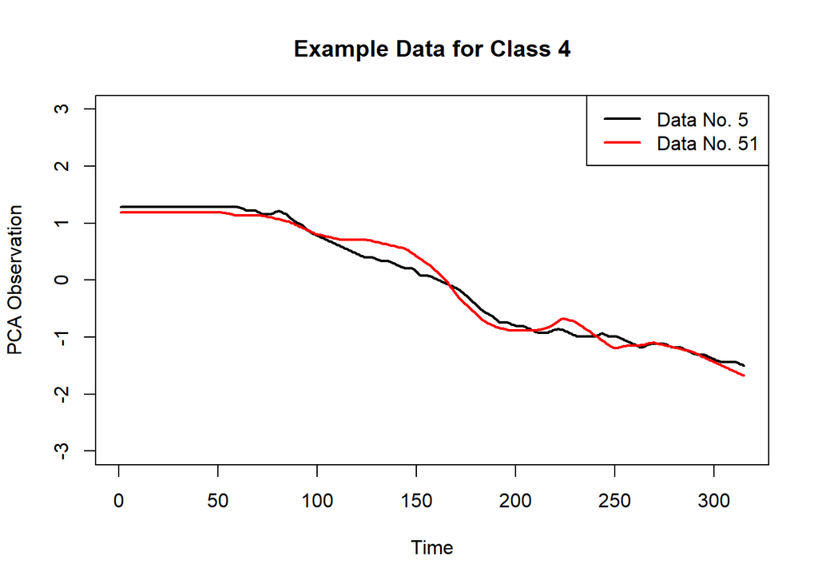

```r
plot(time, dataForPartB[t4_1,1], type = "l", ylim=c(-3, 3), lwd=2, main = "Example Data for Class 4", xlab="Time", ylab="PCA Observation")
lines(time, dataForPartB[t4_2,1], col="red", lwd=2)
legend("topright", legend = c(paste("Data No.",randomChoiceClass4_1) , paste("Data No.",randomChoiceClass4_2)),
       col = c("black", "red"), lty = 1:1, lwd = 2)
```

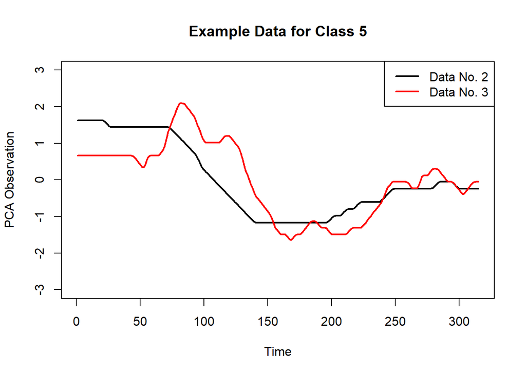

```r
plot(time, dataForPartB[t5_1,1], type = "l", ylim=c(-3, 3), lwd=2, main = "Example Data for Class 5", xlab="Time", ylab="PCA Observation")
lines(time, dataForPartB[t5_2,1], col="red", lwd=2)
legend("topright", legend = c(paste("Data No.",randomChoiceClass5_1) , paste("Data No.",randomChoiceClass5_2)),
       col = c("black", "red"), lty = 1:1, lwd = 2)
```

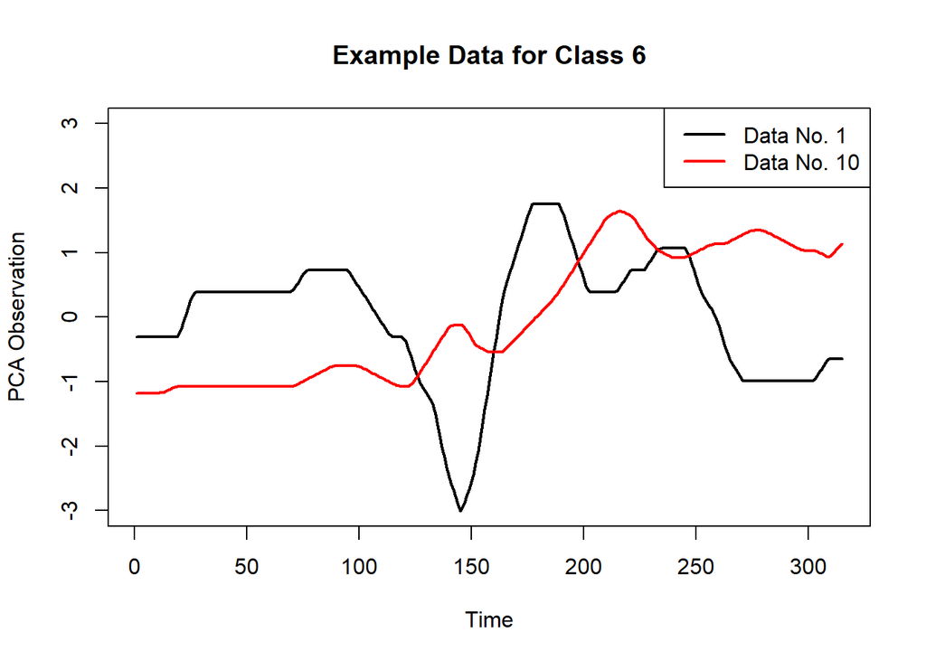

```r
plot(time, dataForPartB[t6_1,1], type = "l", ylim=c(-3, 3), lwd=2, main = "Example Data for Class 6", xlab="Time", ylab="PCA Observation")
lines(time, dataForPartB[t6_2,1], col="red", lwd=2)
legend("topright", legend = c(paste("Data No.",randomChoiceClass6_1) , paste("Data No.",randomChoiceClass6_2)),
       col = c("black", "red"), lty = 1:1, lwd = 2)
```

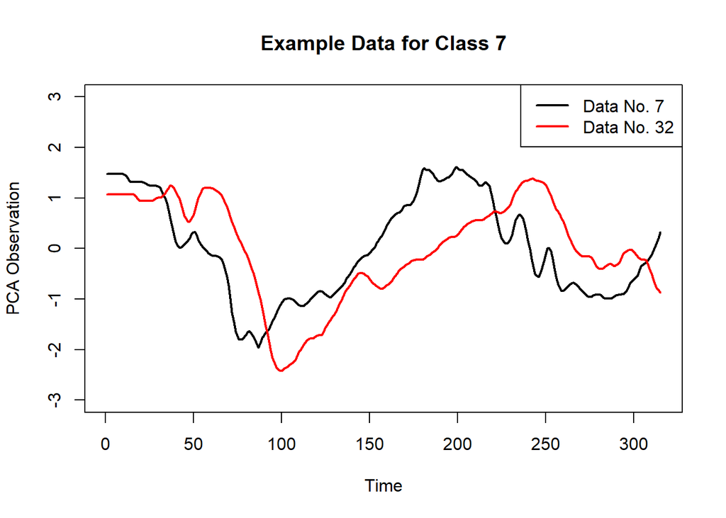

```r
plot(time, dataForPartB[t7_1,1], type = "l", ylim=c(-3, 3), lwd=2, main = "Example Data for Class 7", xlab="Time", ylab="PCA Observation")
lines(time, dataForPartB[t7_2,1], col="red", lwd=2)
legend("topright", legend = c(paste("Data No.",randomChoiceClass7_1) , paste("Data No.",randomChoiceClass7_2)),
       col = c("black", "red"), lty = 1:1, lwd = 2)
```

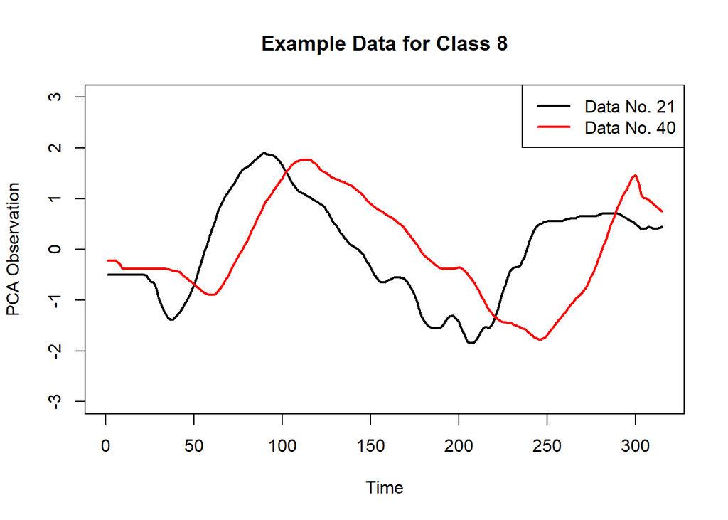

```r
plot(time, dataForPartB[t8_1,1], type = "l", ylim=c(-3, 3), lwd=2, main = "Example Data for Class 8", xlab="Time", ylab="PCA Observation")
lines(time, dataForPartB[t8_2,1], col="red", lwd=2)
legend("topright", legend = c(paste("Data No.",randomChoiceClass8_1) , paste("Data No.",randomChoiceClass8_2)),
       col = c("black", "red"), lty = 1:1, lwd = 2)
```

In Figure 1, it seems like there is a relation between these two instances. It can be said that there are one big peak and one deep valley in both instances over time. In Figure 2, two instances are very similar. One instance is noisier than the other instance however, they have the same characteristics. In Figure 3, instances look alike. There is again a noise difference between instances. It can be said that, Figure 4 has the best fit when we compare these randomly selected instances. They have very similar changes over time. For Figure 5, we can say that these instances have similar characteristics. One instance has more noise factor than the other instance. For Figure 6, we can say that these instances do not have much in common however, there is a slight resemblance. Most importantly, when we compare these characteristics of two instances with other classes, we do not observe any resemblance. We see a great resemblance in Figure 7. Two instances have similar characteristics. In Figure 8, we observe a shift in time between two instances. Also, there is a slight noise level difference. However, they still have very similar characteristics.

## PART C

Now, we filter the data for each class. Then we apply PCA for every single class separately.

Class1:

```r
combineAll = as.data.frame(combineAll)

dataForPartC_1<-cbind(combineAll[which(combineAll$Class==1),3],combineAll[which(combineAll$Class==1),4],combineAll[which(combineAll$Class==1),5])
pcaPartC_1<-princomp(dataForPartC_1)
summary(pcaPartC_1,loadings = TRUE)
```

```
## Importance of components:
##                           Comp.1    Comp.2    Comp.3
## Standard deviation     1.1760927 0.9830166 0.8006000
## Proportion of Variance 0.4625331 0.3231331 0.2143339
## Cumulative Proportion  0.4625331 0.7856661 1.0000000
##
## Loadings:
##      Comp.1 Comp.2 Comp.3
## [1,]  0.357  0.896  0.263
## [2,]  0.691        -0.720
## [3,]  0.629 -0.439  0.642
```

Class2:

```r
dataForPartC_2<-cbind(combineAll[which(combineAll$Class==2),3],combineAll[which(combineAll$Class==2),4],combineAll[which(combineAll$Class==2),5])
pcaPartC_2<-princomp(dataForPartC_2)
summary(pcaPartC_2,loadings = TRUE)
```

```
## Importance of components:
##                           Comp.1    Comp.2    Comp.3
## Standard deviation     1.2380477 0.9667324 0.7232858
## Proportion of Variance 0.5125479 0.3125160 0.1749361
## Cumulative Proportion  0.5125479 0.8250639 1.0000000
##
## Loadings:
##      Comp.1 Comp.2 Comp.3
## [1,]  0.455  0.801  0.388
## [2,]  0.685        -0.728
## [3,]  0.569 -0.597  0.565
```

Class3:

```r
dataForPartC_3<-cbind(combineAll[which(combineAll$Class==3),3],combineAll[which(combineAll$Class==3),4],combineAll[which(combineAll$Class==3),5])
pcaPartC_3<-princomp(dataForPartC_3)
summary(pcaPartC_3,loadings = TRUE)
```

```
## Importance of components:
##                          Comp.1    Comp.2    Comp.3
## Standard deviation     1.271645 0.9460372 0.6916702
## Proportion of Variance 0.540744 0.2992789 0.1599771
## Cumulative Proportion  0.540744 0.8400229 1.0000000
##
## Loadings:
##      Comp.1 Comp.2 Comp.3
## [1,]  0.675         0.738
## [2,]  0.531  0.689 -0.494
## [3,] -0.513  0.725  0.460
```

Class4:

```r
dataForPartC_4<-cbind(combineAll[which(combineAll$Class==4),3],combineAll[which(combineAll$Class==4),4],combineAll[which(combineAll$Class==4),5])
pcaPartC_4<-princomp(dataForPartC_4)
summary(pcaPartC_4,loadings = TRUE)
```

```
## Importance of components:
##                           Comp.1    Comp.2    Comp.3
## Standard deviation     1.2826327 0.9590307 0.6523722
## Proportion of Variance 0.5501287 0.3075563 0.1423150
## Cumulative Proportion  0.5501287 0.8576850 1.0000000
##
## Loadings:
##      Comp.1 Comp.2 Comp.3
## [1,]  0.681  0.113  0.724
## [2,]  0.634  0.404 -0.659
## [3,] -0.367  0.908  0.204
```

Class5:

```r
dataForPartC_5<-cbind(combineAll[which(combineAll$Class==5),3],combineAll[which(combineAll$Class==5),4],combineAll[which(combineAll$Class==5),5])
pcaPartC_5<-princomp(dataForPartC_5)
summary(pcaPartC_5,loadings = TRUE)
```

```
## Importance of components:
##                           Comp.1    Comp.2     Comp.3
## Standard deviation     1.3912247 0.9062088 0.48348277
## Proportion of Variance 0.6472234 0.2746099 0.07816668
## Cumulative Proportion  0.6472234 0.9218333 1.00000000
##
## Loadings:
##      Comp.1 Comp.2 Comp.3
## [1,]  0.399  0.915
## [2,]  0.643 -0.321  0.696
## [3,]  0.654 -0.243 -0.716
```

Class6:

```r
dataForPartC_6<-cbind(combineAll[which(combineAll$Class==6),3],combineAll[which(combineAll$Class==6),4],combineAll[which(combineAll$Class==6),5])
pcaPartC_6<-princomp(dataForPartC_6)
summary(pcaPartC_6,loadings = TRUE)
```

```
## Importance of components:
##                           Comp.1    Comp.2     Comp.3
## Standard deviation     1.3076795 0.9925902 0.54333711
## Proportion of Variance 0.5718239 0.3294577 0.09871846
## Cumulative Proportion  0.5718239 0.9012815 1.00000000
##
## Loadings:
##      Comp.1 Comp.2 Comp.3
## [1,]  0.206  0.964  0.167
## [2,] -0.680  0.264 -0.684
## [3,] -0.704         0.710
```

Class7:

```r
dataForPartC_7<-cbind(combineAll[which(combineAll$Class==7),3],combineAll[which(combineAll$Class==7),4],combineAll[which(combineAll$Class==7),5])
pcaPartC_7<-princomp(dataForPartC_7)
summary(pcaPartC_7,loadings = TRUE)
```

```
## Importance of components:
##                           Comp.1    Comp.2    Comp.3
## Standard deviation     1.2460598 1.0128304 0.6418611
## Proportion of Variance 0.5192033 0.3430308 0.1377659
## Cumulative Proportion  0.5192033 0.8622341 1.0000000
##
## Loadings:
##      Comp.1 Comp.2 Comp.3
## [1,]  0.229  0.925  0.304
## [2,]  0.715        -0.697
## [3,]  0.661 -0.377  0.649
```

Class8:

```r
dataForPartC_8<-cbind(combineAll[which(combineAll$Class==8),3],combineAll[which(combineAll$Class==8),4],combineAll[which(combineAll$Class==8),5])
pcaPartC_8<-princomp(dataForPartC_8)
summary(pcaPartC_8,loadings = TRUE)
```

```
## Importance of components:
##                           Comp.1    Comp.2     Comp.3
## Standard deviation     1.3544144 0.9660374 0.47202702
## Proportion of Variance 0.6134269 0.3120668 0.07450636
## Cumulative Proportion  0.6134269 0.9254936 1.00000000
##
## Loadings:
##      Comp.1 Comp.2 Comp.3
## [1,]  0.574  0.584  0.574
## [2,]  0.693        -0.721
## [3,]  0.436 -0.811  0.389
```

PCA results (components, variance covered by each component) are listed above. By looking at every PC1 components of classes, we observe that the standard deviation values are closer to each other. In other words, the first components seem similar. However, when we compare the loadings, we observe a difference. These may show that 8 classes can be distinguished.

## PART D

Calculating distances, obtaining a symmetric distance matrix, and applying MDS.

```r
XYZ <- cbind(dataX[,-1],dataY[,-1],dataZ[,-1])
asd<-dist(XYZ)
temp<-cmdscale(asd,k=2)
dataForPartD<-cbind(dataX[,1],temp)
dataForPartD_wClass<-as.data.frame(dataForPartD)
#plot(temp,col = dataForPartD_wClass$X1, lwd = 2)
#legend("bottomright", legend = c("1","2","3","4","5","6","7","8"), col = rainbow(8),lwd = 2)
colnames(dataForPartD_wClass,do.NULL = TRUE, prefix = "col")
```

```
## [1] "X1" "1"  "2"
```

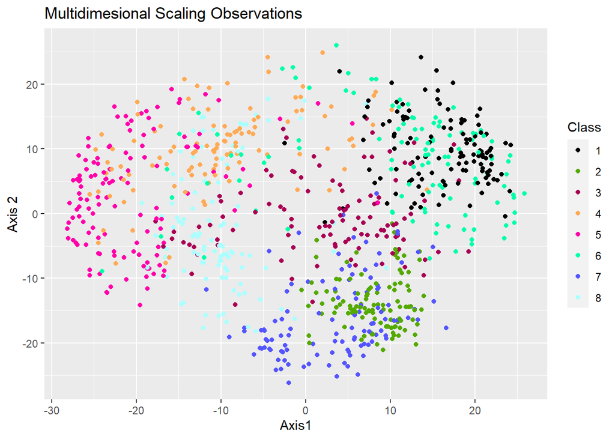

```r
colnames(dataForPartD_wClass)<-c("Class", "A","B")
ggplot(dataForPartD_wClass) + geom_point(aes(x=A, y=B, color=as.factor(Class))) +
labs(title="Multidimesional Scaling Observations", y="Axis 2", x="Axis1") +
scale_color_manual(name = "Class",
                     breaks = c("1", "2", "3","4","5","6","7","8"),
                     values = primary.colors(8, steps = 3.75, no.white = TRUE))
```

By looking at the figure above, we can say that the noise(variance) is high almost in every Class type. Furthermore, we see that classes create clusters but, their center points are close to each other and due to high variance, clusters overlap. This means MDS observation is not very useful to distinguish the classes(gestures), but nevertheless, we can have some opinion about classes by looking at these results.